# Klarna Case Study - Machine Learning

Author: **Paul Egorov**

Date: 2021-11-07

Email: spry.amp.0w@icloud.com

### Case Description

This case consists of a supervised learning example, similar to what some Klarna teams are working with on a daily basis.

Your task is to predict the probability of default for the data points in the attached le where that variable is missing. Your solution should contain your predictions in a .csv le with two columns, uuid and pd (probability of default==1). Once done, you should expose this model with an API endpoint on a cloud provider of your choice. We (mostly) use Python for modeling at Klarna so please use this programming language to craft your submission. There’s a bonus point if you use AWS in your deployment.

When you’re ready, send us your solution. Include the code, details on how to query the endpoint, and a 1-pager that summarizes how you built and validated your model.

Our advice is to avoid spending too much time optimizing your prediction results. We want to evaluate how you structure, reason and evaluate the problem. Showing off your skills in model building, analysis, and software engineering is more important than maximizing predictive performance. Similarly, further information about the variables below is not available, as your domain knowledge and skills in business translation will be assessed at a later stage. Good luck!!

# 1. Exploratory Data Analysis

Let's import dataset and do some EDA for better data understanding

```python
import pandas as pd
import os

import matplotlib.pyplot as plt
import seaborn as sns
import missingno as msno

import numpy as np
import utils
%matplotlib inline
%config InlineBackend.figure_format='retina'
```

```python
df = pd.read_csv(os.path.join(os.pardir, 'data', 'dataset.csv'), sep = ';')
```

## 1.1 General info about dataset

```python
df.T
```

|  | 0 | 1 | 2 | 3 | 4 | 5 | 6 | 7 | 8 | 9 | ... | 99966 | 99967 | 99968 | 99969 | 99970 | 99971 | 99972 | 99973 | 99974 | 99975 |
| --- | --- | --- | --- | --- | --- | --- | --- | --- | --- | --- | --- | --- | --- | --- | --- | --- | --- | --- | --- | --- | --- |
| uuid | 63f69b2c-8b1c-4740-b78d-52ed9a4515ac | 0e961183-8c15-4470-9a5e-07a1bd207661 | d8edaae6-4368-44e0-941e-8328f203e64e | 0095dfb6-a886-4e2a-b056-15ef45fdb0ef | c8f8b835-5647-4506-bf15-49105d8af30b | 0c266e3c-910f-49c1-af6f-32b7c492eb58 | 29b7e418-f057-44fc-8d5c-50015b5a5856 | 575cebe3-2807-4dcb-8047-cf4ca9476a4d | 320f1544-064f-4568-a5f0-4ed54e91483a | d483d718-eace-4685-ace2-c0579911f196 | ... | 34094999-c04b-4b8d-a404-84e612a24b11 | 9610e28b-3ca1-45cf-8b83-2ae06e82dabc | 243fa082-bdf6-4a6f-81ee-41b28e6bb688 | 57e92a56-7145-4ea2-92d5-fb79388d82c1 | 0e5e16e1-7a8b-41a8-bc9d-8fac11e3abc1 | 5c03bc63-ea65-4ffd-aa7b-95ea9a46db34 | f8db22f4-9819-420c-abbc-9ddf1843176e | b22e21ea-b1b2-4df3-b236-0ff6d5fdc0d8 | bafcab15-9898-479c-b729-c9dda7edb78f | ac88f18c-96a6-49bc-9e9d-a780225914af |
| default | 0.0 | 0.0 | 0.0 | 0.0 | 0.0 | 0.0 | 0.0 | 0.0 | 0.0 | 0.0 | ... | NaN | NaN | NaN | NaN | NaN | NaN | NaN | NaN | NaN | NaN |
| account_amount_added_12_24m | 0 | 0 | 0 | 0 | 0 | 0 | 0 | 57229 | 148922 | 0 | ... | 16642 | 32355 | 0 | 0 | 88405 | 0 | 0 | 45671 | 56102 | 0 |
| account_days_in_dc_12_24m | 0.0 | 0.0 | 0.0 | NaN | 0.0 | 0.0 | 0.0 | 0.0 | 0.0 | 0.0 | ... | 0.0 | 0.0 | 0.0 | 365.0 | 0.0 | 0.0 | 0.0 | 0.0 | 0.0 | 0.0 |
| account_days_in_rem_12_24m | 0.0 | 0.0 | 0.0 | NaN | 0.0 | 0.0 | 142.0 | 0.0 | 47.0 | 0.0 | ... | 59.0 | 125.0 | 0.0 | 0.0 | 15.0 | 0.0 | 0.0 | 20.0 | 0.0 | 0.0 |
| account_days_in_term_12_24m | 0.0 | 0.0 | 0.0 | NaN | 0.0 | 0.0 | 0.0 | 0.0 | 0.0 | 0.0 | ... | 0.0 | 44.0 | 0.0 | 0.0 | 0.0 | 0.0 | 0.0 | 0.0 | 0.0 | 0.0 |
| account_incoming_debt_vs_paid_0_24m | 0.0 | NaN | NaN | NaN | NaN | NaN | 0.0 | 0.232244 | 0.969055 | NaN | ... | 0.0 | 0.665829 | NaN | 0.371604 | 0.672 | NaN | 0.004044 | 0.705078 | 0.064175 | NaN |
| account_status | 1.0 | 1.0 | NaN | NaN | NaN | NaN | 1.0 | 1.0 | 1.0 | NaN | ... | 1.0 | 2.0 | NaN | 1.0 | 2.0 | 1.0 | 1.0 | 2.0 | 1.0 | 1.0 |
| account_worst_status_0_3m | 1.0 | 1.0 | NaN | NaN | NaN | NaN | 2.0 | 1.0 | 2.0 | NaN | ... | 1.0 | 2.0 | NaN | 1.0 | 2.0 | 1.0 | 1.0 | 2.0 | 2.0 | 1.0 |
| account_worst_status_12_24m | NaN | 1.0 | NaN | NaN | NaN | NaN | 2.0 | 1.0 | 2.0 | NaN | ... | 2.0 | 3.0 | NaN | 4.0 | 2.0 | NaN | NaN | 2.0 | 1.0 | NaN |
| account_worst_status_3_6m | 1.0 | 1.0 | NaN | NaN | NaN | NaN | 1.0 | 1.0 | 2.0 | NaN | ... | 1.0 | 2.0 | NaN | 1.0 | 1.0 | NaN | 1.0 | 1.0 | 2.0 | 1.0 |
| account_worst_status_6_12m | NaN | 1.0 | NaN | NaN | NaN | NaN | 3.0 | 1.0 | 2.0 | NaN | ... | 1.0 | 2.0 | NaN | 4.0 | 2.0 | NaN | 1.0 | 1.0 | 2.0 | NaN |
| age | 20 | 50 | 22 | 36 | 25 | 18 | 49 | 34 | 40 | 47 | ... | 40 | 28 | 45 | 31 | 21 | 33 | 44 | 24 | 31 | 41 |
| avg_payment_span_0_12m | 12.692308 | 25.833333 | 20.0 | 4.6875 | 13.0 | NaN | 3.0 | 26.930233 | 33.727273 | 21.0 | ... | 40.0 | 12.0 | 17.090909 | NaN | NaN | 10.333333 | 36.0 | NaN | 17.5 | 34.666667 |
| avg_payment_span_0_3m | 8.333333 | 25.0 | 18.0 | 4.888889 | 13.0 | NaN | 3.0 | 25.866667 | 37.571429 | 21.25 | ... | 16.0 | NaN | 20.714286 | NaN | NaN | NaN | NaN | NaN | NaN | 37.5 |
| merchant_category | Dietary supplements | Books & Magazines | Diversified entertainment | Diversified entertainment | Electronic equipment & Related accessories | Dietary supplements | Concept stores & Miscellaneous | Diversified entertainment | Diversified entertainment | Diversified entertainment | ... | Youthful Shoes & Clothing | Kitchenware | Diversified entertainment | Hobby articles | Body & Hair Care | Electronic equipment & Related accessories | Body & Hair Care | Jewelry & Watches | Decoration & Art | Dietary supplements |
| merchant_group | Health & Beauty | Entertainment | Entertainment | Entertainment | Electronics | Health & Beauty | Leisure, Sport & Hobby | Entertainment | Entertainment | Entertainment | ... | Clothing & Shoes | Home & Garden | Entertainment | Leisure, Sport & Hobby | Health & Beauty | Electronics | Health & Beauty | Jewelry & Accessories | Home & Garden | Health & Beauty |
| has_paid | True | True | True | True | True | False | True | True | True | True | ... | True | True | True | True | True | True | True | True | True | True |
| max_paid_inv_0_12m | 31638.0 | 13749.0 | 29890.0 | 40040.0 | 7100.0 | 0.0 | 2373.0 | 8655.0 | 6075.0 | 36985.0 | ... | 11835.0 | 9330.0 | 12264.0 | 895.0 | 0.0 | 35195.0 | 4740.0 | 1200.0 | 15000.0 | 13246.0 |
| max_paid_inv_0_24m | 31638.0 | 13749.0 | 29890.0 | 40040.0 | 7100.0 | 0.0 | 2373.0 | 9645.0 | 9090.0 | 36985.0 | ... | 11835.0 | 9330.0 | 12264.0 | 895.0 | 6242.0 | 35195.0 | 4740.0 | 1200.0 | 15000.0 | 14817.0 |
| name_in_email | no_match | F+L | L1+F | F1+L | F+L | L1+F | L1+F | F | Nick | Nick | ... | F+L | F+L | Nick | L1+F | no_match | F1+L | F1+L | Nick | Nick | F1+L |
| num_active_div_by_paid_inv_0_12m | 0.153846 | 0.0 | 0.071429 | 0.03125 | 0.0 | NaN | 0.0 | 0.083333 | 0.818182 | 0.0 | ... | 0.142857 | 0.0 | 0.037975 | NaN | NaN | 0.0 | 0.0 | NaN | 0.0 | 0.0 |
| num_active_inv | 2 | 0 | 1 | 1 | 0 | 0 | 0 | 20 | 9 | 0 | ... | 1 | 0 | 3 | 0 | 0 | 0 | 0 | 0 | 0 | 0 |
| num_arch_dc_0_12m | 0 | 0 | 0 | 0 | 0 | 0 | 0 | 0 | 0 | 0 | ... | 0 | 0 | 0 | 0 | 0 | 0 | 0 | 0 | 0 | 0 |
| num_arch_dc_12_24m | 0 | 0 | 0 | 0 | 0 | 0 | 0 | 0 | 0 | 0 | ... | 0 | 0 | 0 | 0 | 0 | 0 | 0 | 0 | 0 | 0 |
| num_arch_ok_0_12m | 13 | 9 | 11 | 31 | 1 | 0 | 1 | 215 | 3 | 5 | ... | 2 | 1 | 77 | 0 | 0 | 6 | 1 | 0 | 2 | 2 |
| num_arch_ok_12_24m | 14 | 19 | 0 | 21 | 0 | 0 | 0 | 257 | 2 | 10 | ... | 5 | 0 | 44 | 0 | 2 | 2 | 3 | 0 | 1 | 2 |
| num_arch_rem_0_12m | 0 | 3 | 3 | 0 | 0 | 0 | 0 | 0 | 3 | 0 | ... | 5 | 0 | 0 | 0 | 0 | 0 | 0 | 0 | 0 | 1 |
| num_arch_written_off_0_12m | 0.0 | 0.0 | 0.0 | 0.0 | 0.0 | NaN | 0.0 | 0.0 | 0.0 | 0.0 | ... | 0.0 | 0.0 | 0.0 | NaN | 0.0 | 0.0 | 0.0 | NaN | 0.0 | 0.0 |
| num_arch_written_off_12_24m | 0.0 | 0.0 | 0.0 | 0.0 | 0.0 | NaN | 0.0 | 0.0 | 0.0 | 0.0 | ... | 0.0 | 0.0 | 0.0 | NaN | 0.0 | 0.0 | 0.0 | NaN | 0.0 | 0.0 |
| num_unpaid_bills | 2 | 0 | 1 | 1 | 0 | 0 | 0 | 37 | 23 | 0 | ... | 2 | 16 | 3 | 2 | 9 | 0 | 1 | 18 | 1 | 1 |
| status_last_archived_0_24m | 1 | 1 | 1 | 1 | 1 | 0 | 1 | 1 | 1 | 1 | ... | 1 | 1 | 1 | 0 | 1 | 1 | 1 | 0 | 1 | 2 |
| status_2nd_last_archived_0_24m | 1 | 1 | 1 | 1 | 0 | 0 | 0 | 1 | 2 | 1 | ... | 2 | 0 | 1 | 0 | 1 | 1 | 1 | 0 | 1 | 1 |
| status_3rd_last_archived_0_24m | 1 | 1 | 1 | 1 | 0 | 0 | 0 | 1 | 2 | 1 | ... | 2 | 0 | 1 | 0 | 0 | 1 | 1 | 0 | 1 | 1 |
| status_max_archived_0_6_months | 1 | 1 | 1 | 1 | 1 | 0 | 1 | 1 | 2 | 1 | ... | 2 | 1 | 1 | 0 | 0 | 1 | 0 | 0 | 1 | 2 |
| status_max_archived_0_12_months | 1 | 2 | 2 | 1 | 1 | 0 | 1 | 1 | 2 | 1 | ... | 2 | 1 | 1 | 0 | 0 | 1 | 1 | 0 | 1 | 2 |
| status_max_archived_0_24_months | 1 | 2 | 2 | 1 | 1 | 0 | 1 | 1 | 2 | 1 | ... | 2 | 1 | 1 | 0 | 1 | 1 | 1 | 0 | 1 | 2 |
| recovery_debt | 0 | 0 | 0 | 0 | 0 | 0 | 0 | 0 | 0 | 0 | ... | 0 | 0 | 0 | 0 | 0 | 0 | 0 | 0 | 0 | 0 |
| sum_capital_paid_account_0_12m | 0 | 0 | 0 | 0 | 0 | 0 | 18760 | 42206 | 104643 | 0 | ... | 12738 | 20633 | 0 | 7695 | 28870 | 0 | 7948 | 17447 | 18339 | 0 |
| sum_capital_paid_account_12_24m | 0 | 0 | 0 | 0 | 0 | 0 | 8337 | 35336 | 32381 | 0 | ... | 10852 | 22355 | 0 | 1025 | 25771 | 0 | 0 | 19627 | 56180 | 0 |
| sum_paid_inv_0_12m | 178839 | 49014 | 124839 | 324676 | 7100 | 0 | 2373 | 457257 | 24390 | 78620 | ... | 44244 | 10225 | 276135 | 895 | 0 | 60127 | 4740 | 3100 | 34785 | 30602 |
| time_hours | 9.653333 | 13.181389 | 11.561944 | 15.751111 | 12.698611 | 18.328333 | 10.244444 | 12.192778 | 21.411111 | 13.340833 | ... | 17.471389 | 13.0575 | 19.786944 | 11.290833 | 9.060833 | 10.765556 | 21.708333 | 2.185278 | 9.725278 | 11.585278 |
| worst_status_active_inv | 1.0 | NaN | 1.0 | 1.0 | NaN | NaN | NaN | 1.0 | 1.0 | NaN | ... | 1.0 | NaN | 1.0 | NaN | NaN | NaN | NaN | NaN | NaN | NaN |

43 rows × 99976 columns

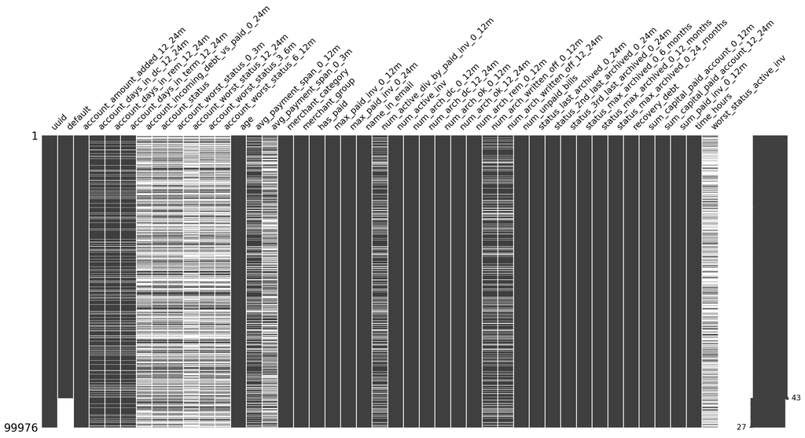

```python
msno.matrix(df)
```

- Seems that missing values have interesting "vertical" structure: thare are some columns, which totally ok.
- Also we have some missing data in target variable "default".

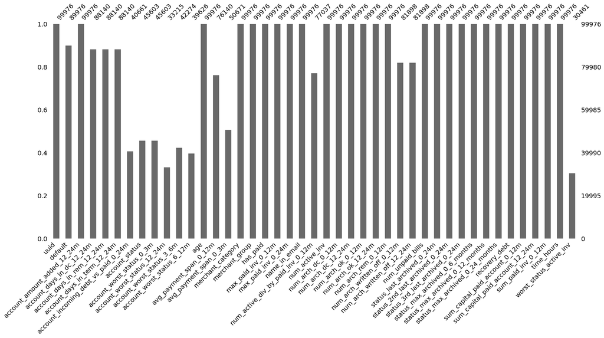

```python
msno.bar(df)
```

## 1.2 Target variable distribution

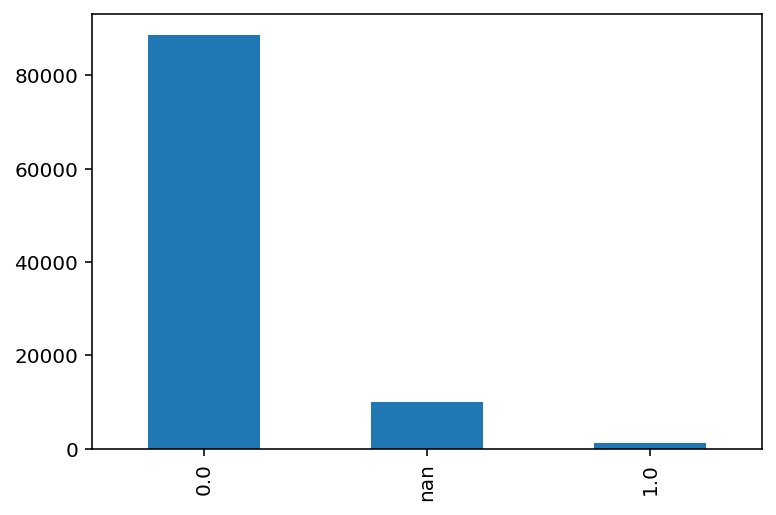

```python
df['default'].astype('str').value_counts().plot(kind = 'bar')
```

```python
df['default'].astype('str').value_counts()
```

```
0.0    88688
nan    10000
1.0     1288
Name: default, dtype: int64
```

As expected, there is huge data imbalance in the target variable.

Also we have **10k!** missing target variables.

## 1.3 General correlations

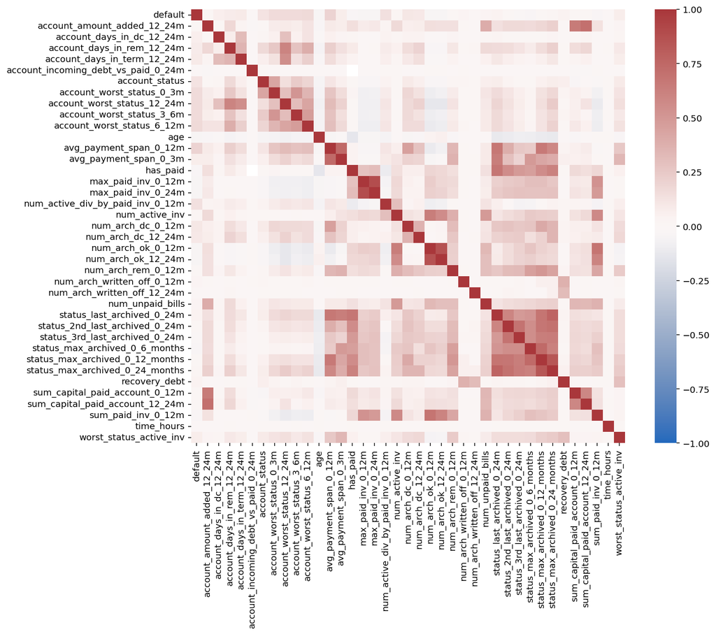

```python
utils.heatmap_corr(df)
```

We can see interesting squared structure. It means, that our features already have several aggregates, line status_0_24..., status2nd, status_3rd, status_0_12.. etc

```python
cols_corr_df = df.corr().head(1).T.sort_values(by=['default'], ascending=False)
cols_corr_df
```

|  | default |
| --- | --- |
| default | 1.000000 |
| avg_payment_span_0_12m | 0.197384 |
| account_worst_status_6_12m | 0.168975 |
| account_worst_status_0_3m | 0.159137 |
| account_worst_status_12_24m | 0.158235 |
| account_worst_status_3_6m | 0.156539 |
| num_active_div_by_paid_inv_0_12m | 0.137428 |
| account_status | 0.120683 |
| num_arch_dc_0_12m | 0.107296 |
| num_arch_dc_12_24m | 0.100891 |
| account_days_in_term_12_24m | 0.086796 |
| account_days_in_rem_12_24m | 0.085565 |
| avg_payment_span_0_3m | 0.073332 |
| worst_status_active_inv | 0.072068 |
| account_days_in_dc_12_24m | 0.065545 |
| recovery_debt | 0.044840 |
| status_last_archived_0_24m | 0.039660 |
| num_unpaid_bills | 0.027368 |
| num_arch_written_off_0_12m | 0.023603 |
| status_max_archived_0_24_months | 0.022469 |
| num_active_inv | 0.018895 |
| account_amount_added_12_24m | 0.005819 |
| sum_capital_paid_account_12_24m | 0.003802 |
| status_max_archived_0_12_months | 0.002335 |
| sum_capital_paid_account_0_12m | 0.002082 |
| status_2nd_last_archived_0_24m | 0.001585 |
| num_arch_rem_0_12m | 0.000635 |
| account_incoming_debt_vs_paid_0_24m | -0.000627 |
| num_arch_written_off_12_24m | -0.001134 |
| time_hours | -0.010196 |
| status_3rd_last_archived_0_24m | -0.016953 |
| has_paid | -0.032081 |
| status_max_archived_0_6_months | -0.032993 |
| sum_paid_inv_0_12m | -0.035583 |
| max_paid_inv_0_12m | -0.042296 |
| num_arch_ok_12_24m | -0.042732 |
| max_paid_inv_0_24m | -0.043468 |
| age | -0.043728 |
| num_arch_ok_0_12m | -0.046578 |

## 1.4 Declaring columns types

Declaring columns metadata from case study description

```python
numeric_cols =['account_amount_added_12_24m',
               'account_days_in_dc_12_24m',
               'account_days_in_rem_12_24m',
               'account_days_in_term_12_24m',
               'account_incoming_debt_vs_paid_0_24m',
               'age',
               'avg_payment_span_0_12m',
               'avg_payment_span_0_3m',
               'max_paid_inv_0_12m',
               'max_paid_inv_0_24m',
               'num_active_div_by_paid_inv_0_12m',
               'num_active_inv',
               'num_arch_dc_0_12m',
               'num_arch_dc_12_24m',
               'num_arch_ok_0_12m',
               'num_arch_ok_12_24m',
               'num_arch_rem_0_12m',
               'num_arch_written_off_0_12m',
               'num_arch_written_off_12_24m',
               'num_unpaid_bills',
               'recovery_debt',
               'sum_capital_paid_account_0_12m',
               'sum_capital_paid_account_12_24m',
               'sum_paid_inv_0_12m',
               'time_hours'
              ]
categorical_num_cols = ['account_status',
                    'account_worst_status_0_3m',
                    'account_worst_status_12_24m',
                    'account_worst_status_3_6m',
                    'account_worst_status_6_12m',
                    'status_last_archived_0_24m',
                   'status_2nd_last_archived_0_24m',
                   'status_3rd_last_archived_0_24m',
                   'status_max_archived_0_6_months',
                   'status_max_archived_0_12_months',
                   'status_max_archived_0_24_months',
                    'worst_status_active_inv'
                   ]
categorical_text_cols = ['merchant_category',
                    'merchant_group',
                    'name_in_email']

boolean_cols = ['has_paid']
```

Check that no column was forgotten

```python
set(list(df.columns)) - set(categorical_text_cols) - set(categorical_num_cols) - set(numeric_cols) - set(boolean_cols)
```

```
{'default', 'uuid'}
```

Ok, great, just target variable and uuid. Let's check the data tupes for numerical columns:

```python
set(list(df[numeric_cols].dtypes.tolist()))
```

```
{dtype('int64'), dtype('float64')}
```

Rather numerical. Ok. Let's check the data tupes for numerical columns:

## 1.5 Exploring categorical features

```python
for col in categorical_num_cols:
    print('Statistics for col', col)
    print(df[col].unique()) # to print categories name only
    print(df[col].value_counts()) # to print count of every category
    print()
```

```
Statistics for col account_status
[ 1. nan  2.  3.  4.]
1.0    43693
2.0     1900
3.0        7
4.0        3
Name: account_status, dtype: int64

Statistics for col account_worst_status_0_3m
[ 1. nan  2.  3.  4.]
1.0    38375
2.0     6678
3.0      443
4.0      107
Name: account_worst_status_0_3m, dtype: int64

Statistics for col account_worst_status_12_24m
[nan  1.  2.  3.  4.]
1.0    23527
2.0     8433
3.0      993
4.0      262
Name: account_worst_status_12_24m, dtype: int64

Statistics for col account_worst_status_3_6m
[ 1. nan  2.  3.  4.]
1.0    35254
2.0     6357
3.0      513
4.0      150
Name: account_worst_status_3_6m, dtype: int64

Statistics for col account_worst_status_6_12m
[nan  1.  3.  2.  4.]
1.0    30703
2.0     8025
3.0      688
4.0      210
Name: account_worst_status_6_12m, dtype: int64

```

[output cut: 44 more lines]

```
Statistics for col status_max_archived_0_24_months
[1 2 0 3 5]
1    47064
2    27038
0    18739
3     7114
5       21
Name: status_max_archived_0_24_months, dtype: int64

Statistics for col worst_status_active_inv
[ 1. nan  2.  3.]
1.0    26922
2.0     3369
3.0      170
Name: worst_status_active_inv, dtype: int64
```

Most of the columns with "status" tag in their name are ordinal, so they don't need additional encoding. But we have 3 columns which are nominal:

```python
for col in categorical_text_cols:
    print('Statistics for col', col)
    print(df[col].unique()) # to print categories name only
    print(df[col].value_counts()) # to print count of every category
    print()
```

```
Statistics for col merchant_category
['Dietary supplements' 'Books & Magazines' 'Diversified entertainment'
 'Electronic equipment & Related accessories'
 'Concept stores & Miscellaneous' 'Youthful Shoes & Clothing'
 'General Shoes & Clothing' 'Prints & Photos'
 'Diversified children products' 'Pet supplies'
 'Diversified Home & Garden products' 'Sports gear & Outdoor'
 'Diversified electronics' 'Diversified Jewelry & Accessories'
 'Travel services' 'Prescription optics' 'Pharmaceutical products'
 'Dating services' 'Diversified Health & Beauty products' 'Children toys'
 'Automotive Parts & Accessories' 'Jewelry & Watches' 'Digital services'
 'Decoration & Art' 'Children Clothes & Nurturing products' 'Kitchenware'
 'Hobby articles' 'Personal care & Body improvement' 'Cosmetics' 'Non'
 'Diversified erotic material' 'Food & Beverage'
 'Video Games & Related accessories' 'Tools & Home improvement'
 'Fragrances' 'Household electronics (whitegoods/appliances)'
 'Wheels & Tires' 'Adult Shoes & Clothing' 'Body & Hair Care' 'Underwear'
 'Furniture' 'Erotic Clothing & Accessories' 'Music & Movies'
 'Cleaning & Sanitary' 'Sex toys' 'Bags & Wallets'
 'Costumes & Party supplies' 'Musical Instruments & Equipment' 'Tobacco'
 'Wine, Beer & Liquor' 'Collectibles' 'Safety products' 'Car electronics'
 'Plants & Flowers' 'Event tickets'
 'Office machines & Related accessories (excl. computers)' 'Education']
Diversified entertainment                                  38614
Youthful Shoes & Clothing                                  11755
Books & Magazines                                           9363
General Shoes & Clothing                                    4597
Concept stores & Miscellaneous                              4406
Sports gear & Outdoor                                       3712
Dietary supplements                                         3101
Diversified children products                               2994
Diversified electronics                                     1844
Prints & Photos                                             1675
Children Clothes & Nurturing products                       1500
Pet supplies                                                1315
Electronic equipment & Related accessories                  1037
Jewelry & Watches                                            911
Hobby articles                                               910
Prescription optics                                          899
Body & Hair Care                                             857
```

[output cut: 57 more lines]

```
Erotic Materials            747
Food & Beverage             364
Name: merchant_group, dtype: int64

Statistics for col name_in_email
['no_match' 'F+L' 'L1+F' 'F1+L' 'F' 'Nick' 'L' 'Initials']
F+L         40389
no_match    16826
L1+F        16089
F            9705
Nick         8310
F1+L         7300
L            1332
Initials       25
Name: name_in_email, dtype: int64
```

## 1.6 Exploring numerical variables

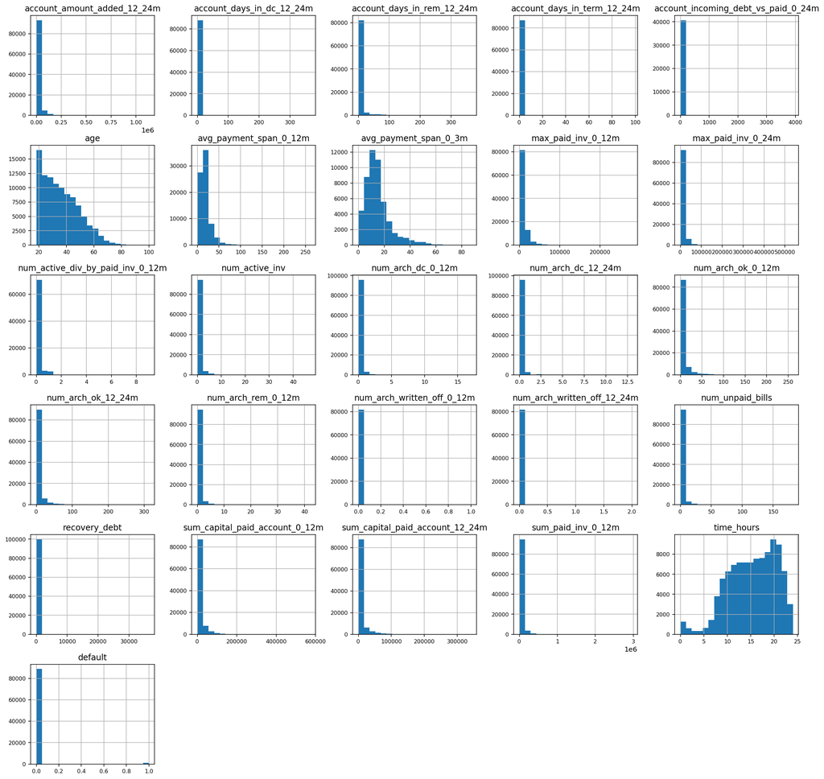

```python
df[numeric_cols + ['default']].hist(figsize=(20, 20),
                      log=False,
            bins=20,
            xlabelsize=8,
            ylabelsize=8);
```

Of course, we see, that data most of meatures don't have normal distrib. Probably, we also have some outliers. But let's just deal with it with RobustScaler. I think it can give good results. But, of course, detailde EDA of each numerical feature can give with respect to bussiness meaning can give better results.

### 1.6.1 Numeric features correlations

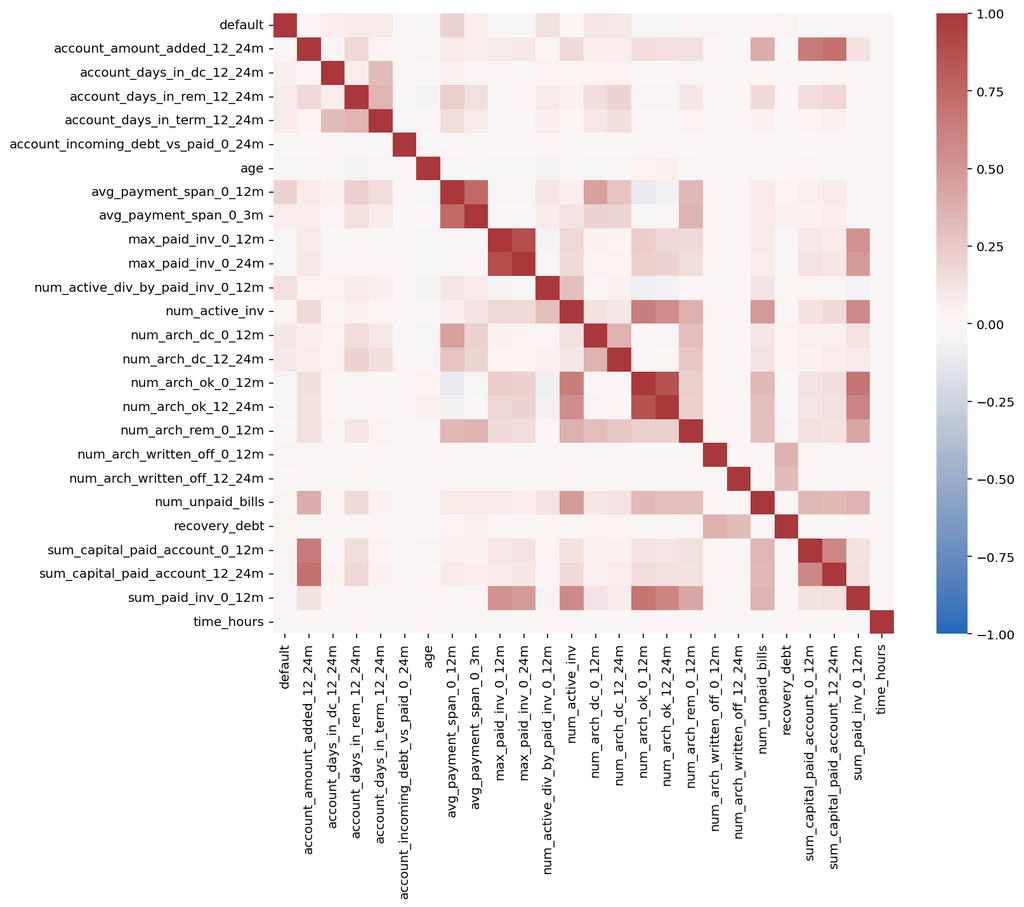

```python
utils.heatmap_corr(df[['default'] + numeric_cols ])
```

```python
numeric_cols_corr_df = df[['default'] + numeric_cols].corr().head(1).T.sort_values(by=['default'], ascending=False)
numeric_cols_corr_df
```

|  | default |
| --- | --- |
| default | 1.000000 |
| avg_payment_span_0_12m | 0.197384 |
| num_active_div_by_paid_inv_0_12m | 0.137428 |
| num_arch_dc_0_12m | 0.107296 |
| num_arch_dc_12_24m | 0.100891 |
| account_days_in_term_12_24m | 0.086796 |
| account_days_in_rem_12_24m | 0.085565 |
| avg_payment_span_0_3m | 0.073332 |
| account_days_in_dc_12_24m | 0.065545 |
| recovery_debt | 0.044840 |
| num_unpaid_bills | 0.027368 |
| num_arch_written_off_0_12m | 0.023603 |
| num_active_inv | 0.018895 |
| account_amount_added_12_24m | 0.005819 |
| sum_capital_paid_account_12_24m | 0.003802 |
| sum_capital_paid_account_0_12m | 0.002082 |
| num_arch_rem_0_12m | 0.000635 |
| account_incoming_debt_vs_paid_0_24m | -0.000627 |
| num_arch_written_off_12_24m | -0.001134 |
| time_hours | -0.010196 |
| sum_paid_inv_0_12m | -0.035583 |
| max_paid_inv_0_12m | -0.042296 |
| num_arch_ok_12_24m | -0.042732 |
| max_paid_inv_0_24m | -0.043468 |
| age | -0.043728 |
| num_arch_ok_0_12m | -0.046578 |

### 1.6.2 Categorical features correlations

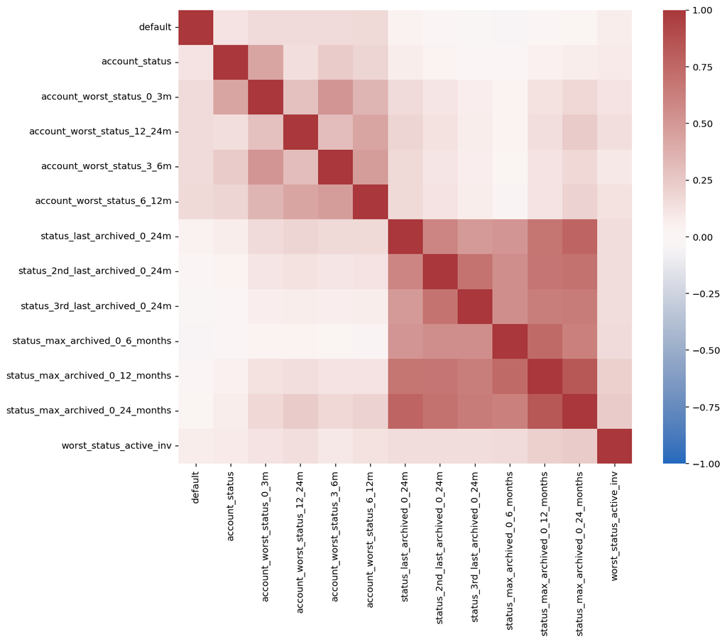

```python
utils.heatmap_corr(df[['default'] + categorical_num_cols ])
```

```python
categorical_num_cols_corr = df[['default'] + categorical_num_cols].corr().head(1).T.sort_values(by=['default'], ascending=False)
categorical_num_cols_corr
```

|  | default |
| --- | --- |
| default | 1.000000 |
| account_worst_status_6_12m | 0.168975 |
| account_worst_status_0_3m | 0.159137 |
| account_worst_status_12_24m | 0.158235 |
| account_worst_status_3_6m | 0.156539 |
| account_status | 0.120683 |
| worst_status_active_inv | 0.072068 |
| status_last_archived_0_24m | 0.039660 |
| status_max_archived_0_24_months | 0.022469 |
| status_max_archived_0_12_months | 0.002335 |
| status_2nd_last_archived_0_24m | 0.001585 |
| status_3rd_last_archived_0_24m | -0.016953 |
| status_max_archived_0_6_months | -0.032993 |

## 1.7 Age vs Default

**Hypothesis:** age can have greate correlation with target, despite of having small correlation value in corr matrix.

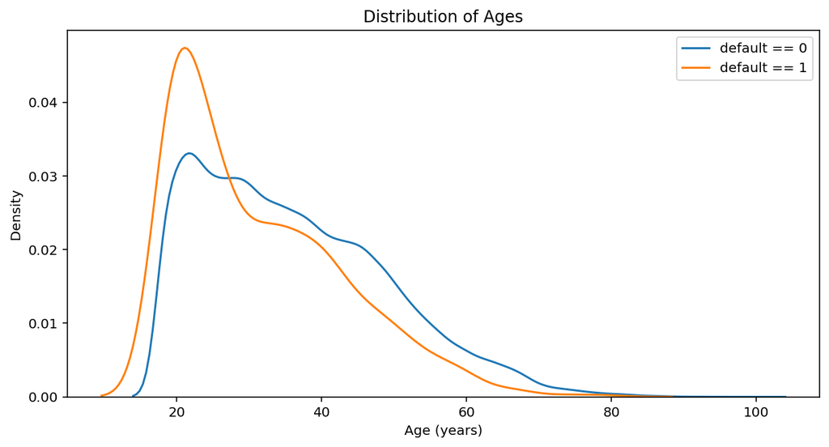

```python
plt.figure(figsize = (10, 5))

# KDE plot of loans that were repaid on time
sns.kdeplot(df[df['default'] == 0]['age'], label = 'default == 0')

# KDE plot of loans which were not repaid on time
sns.kdeplot(df[df['default'] == 1]['age'], label = 'default == 1')

plt.legend()
# Labeling of plot
plt.xlabel('Age (years)');
plt.ylabel('Density');
plt.title('Distribution of Ages');
```

Looks like distribution for default == 1 is skewed to the side of **younger people**. It's intersting, because it means that the age affects the target variable, despite of having rather small correlation coeff (~ -0.04).

```python
age_df = df[['default', 'age']]

# Bin the age data
age_df['age_bins'] = pd.cut(age_df['age'], bins = np.linspace(17, 95, num = 13))#np.linspace(18, 90, num = 13))
age_df.sample(10)
```

|  | default | age | age_bins |
| --- | --- | --- | --- |
| 40899 | 0.0 | 33 | (30.0, 36.5] |
| 48843 | 0.0 | 45 | (43.0, 49.5] |
| 66619 | 0.0 | 33 | (30.0, 36.5] |
| 45760 | 0.0 | 29 | (23.5, 30.0] |
| 1567 | 0.0 | 26 | (23.5, 30.0] |
| 41667 | 0.0 | 31 | (30.0, 36.5] |
| 30843 | 0.0 | 32 | (30.0, 36.5] |
| 87487 | 0.0 | 49 | (43.0, 49.5] |
| 10543 | 0.0 | 24 | (23.5, 30.0] |
| 42448 | 0.0 | 35 | (30.0, 36.5] |

```python
# Group by the bin and calculate averages
age_groups_df  = age_df.groupby('age_bins').mean()
age_groups_df
```

| age_bins | default | age |
| --- | --- | --- |
| (17.0, 23.5] | 0.025070 | 20.511202 |
| (23.5, 30.0] | 0.013982 | 26.991669 |
| (30.0, 36.5] | 0.013271 | 33.443174 |
| (36.5, 43.0] | 0.013237 | 39.863525 |
| (43.0, 49.5] | 0.008902 | 46.379082 |
| (49.5, 56.0] | 0.008470 | 52.664687 |
| (56.0, 62.5] | 0.008870 | 59.238107 |
| (62.5, 69.0] | 0.004188 | 65.522003 |
| (69.0, 75.5] | 0.003110 | 72.121884 |
| (75.5, 82.0] | 0.006369 | 78.454277 |
| (82.0, 88.5] | 0.000000 | 84.787500 |
| (88.5, 95.0] | 0.000000 | 91.153846 |

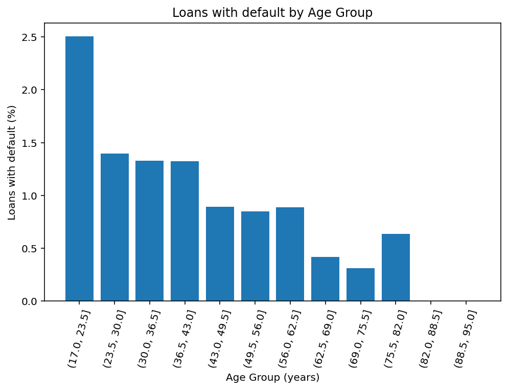

```python
plt.figure(figsize = (8, 5))

# Graph the age bins and the average of the target as a bar plot
plt.bar(age_groups_df.index.astype(str), 100 * age_groups_df['default'])

# Plot labeling
plt.xticks(rotation = 75);
plt.xlabel('Age Group (years)');
plt.ylabel('Loans with default (%)')
plt.title('Loans with default by Age Group');
```

**Trend:** Younger people tend to have a higher probability of having a default. This binning can be used later for features engineering.

# 2. Baseline

```python
from sklearn.dummy import DummyClassifier
from sklearn.model_selection import train_test_split
```

Let drop N/A target variables and create dummy baseline model. Why dropping? Because at this stage experiments with synthetic target variable reconstruction (e.g pseudo labeling...) seem to me a bit premature.

```python
df_bl = df[df['default'].isna() == False]
```

```
F1-score: 0.00
AUC: 0.50

Classification report:
              precision    recall  f1-score   support

 Default = 0       0.99      1.00      0.99     17733
 Default = 1       0.00      0.00      0.00       263

    accuracy                           0.99     17996
   macro avg       0.49      0.50      0.50     17996
weighted avg       0.97      0.99      0.98     17996
```

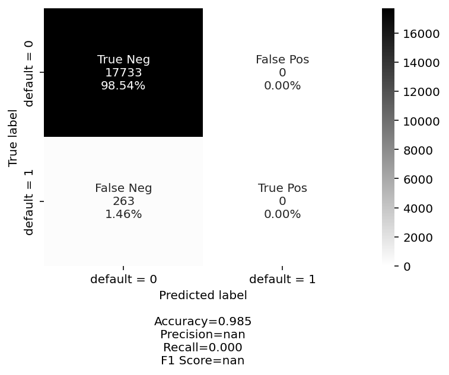

```python
utils.fit_predict_after_split(DummyClassifier(),
            *train_test_split(
                        df_bl.drop(['uuid','default'], axis = 1),
                        df_bl['default'],
                        test_size=0.2,
                        random_state=0)
                             )
```

Great! Accuracy 98.5%. :) And we shouldn't relate to this metric. It is better to see at F1-score metrics. We have really huge imbalance, so F1 can be even better than ROC-AUC.

F1 score for positive class, as expected, equals to zero. Let's try to improve this with not dummy models.

# 3. Modeling

```python
from time import time
import warnings
warnings.filterwarnings('ignore')

# data preprocessing
from sklearn import metrics
from sklearn.compose import ColumnTransformer
from sklearn.pipeline import Pipeline,make_pipeline
from sklearn.impute import SimpleImputer
from sklearn.preprocessing import StandardScaler, OneHotEncoder, RobustScaler, PolynomialFeatures

#models
from sklearn.linear_model import LogisticRegression
from sklearn.tree import DecisionTreeClassifier
from sklearn.ensemble import RandomForestClassifier
from xgboost import XGBClassifier
from lightgbm import LGBMClassifier
```

## 3.2 Special utils function for model evalation

I have created special utility function, which you can find in utils.py. It helped me to evaluate set of model and easily conduct preprocessing experiments. You just set up a list of models (estimators), set up preprocessing pipeline and run utils.evalute_models_cv.

Example:

```
entries_bl, results_bl = utils.evalute_models_cv(estimators,
                  estimators_names,
                  preprocessor,
                  'prep v1',
                  *train_test_split(
                        df_bl.drop(['uuid','default'], axis = 1),
                        df_bl['default'],
                        test_size=0.2,
                        random_state=0)
                 )
```

Output features:

- Name
- f1
- f1_test
- roc_auc_test
- StdDev(%)
- Time(s)
- fpr
- tpr

## 3.3 Set of estimators:

```python
estimators = [

    LogisticRegression(class_weight = 'balanced'),
    RandomForestClassifier(),
    DecisionTreeClassifier(),
    XGBClassifier(),
    LGBMClassifier(),
]
estimators_names = [
    'Logreg',
    'RF',
    'DT',
    'XGB',
    'LGBM',
]
```

## 3.3 Modeling experiment v1

### Preprocessing setup

1. Delete rows with null target variables ('default')
2. Delete columns, which contains null data
3. Apply dummies encoding for nominal_categorical_cols
4. Convert boolean feature to int
5. Apply StandardScaler for numerical columns

```python
df_bl = df_bl[df.columns[(df_bl.isnull().sum() == 0).values]] #2
df_bl[boolean_cols] = df_bl[boolean_cols].astype('int') #4
```

```python
print('Current baseline dataframe shape:', df_bl.shape)
```

```
Current baseline dataframe shape: (89976, 28)
```

```python
numeric_transformer = Pipeline(steps=[('scaler', StandardScaler())])
categorical_transformer = OneHotEncoder(handle_unknown='ignore')

#3,5
preprocessor = ColumnTransformer(
    transformers=[
        ('num', numeric_transformer, list(set(df_bl.columns) & set(numeric_cols  + categorical_num_cols))),
        ('cat', categorical_transformer, list(set(df_bl.columns) & set(categorical_text_cols)))])
```

```python
print('Current baseline dataframe shape (after prep):', preprocessor.fit_transform(df_bl).shape)
```

```
Current baseline dataframe shape (after prep): (89976, 99)
```

```python
entries_bl, results_bl = utils.evalute_models_cv(estimators,
                  estimators_names,
                  preprocessor,
                  'prep v1',
                  *train_test_split(
                        df_bl.drop(['uuid','default'], axis = 1),
                        df_bl['default'],
                        test_size=0.2,
                        random_state=0)
                 )
```

[output not shown]

```python
results_bl.sort_values(by = 'f1_test', ascending= False)
```

|  | Name | f1 | f1_test | roc_auc_test | StdDev(%) | Time(s) | fpr | tpr |
| --- | --- | --- | --- | --- | --- | --- | --- | --- |
| 2 | DT prep v1 | 0.1491 | 0.1429 | 0.5673 | 0.71 | 10.76 | [0.0, 0.013759657136412338, 1.0] | [0.0, 0.1482889733840304, 1.0] |
| 4 | LGBM prep v1 | 0.1289 | 0.1180 | 0.8985 | 3.31 | 2.79 | [0.0, 0.0, 0.0, 0.00011278407488862572, 0.0001... | [0.0, 0.0038022813688212928, 0.011406844106463... |
| 3 | XGB prep v1 | 0.1303 | 0.1141 | 0.8931 | 3.09 | 12.76 | [0.0, 5.639203744431286e-05, 0.000112784074888... | [0.0, 0.0, 0.0, 0.019011406844106463, 0.019011... |
| 0 | Logreg prep v1 | 0.0907 | 0.0970 | 0.8776 | 0.26 | 3.86 | [0.0, 0.0, 0.00039474426211019004, 0.000394744... | [0.0, 0.0038022813688212928, 0.003802281368821... |
| 1 | RF prep v1 | 0.0976 | 0.0783 | 0.8427 | 1.40 | 115.84 | [0.0, 5.639203744431286e-05, 5.639203744431286... | [0.0, 0.0, 0.011406844106463879, 0.01140684410... |

```python
#import imp
#imp.reload(utils)
```

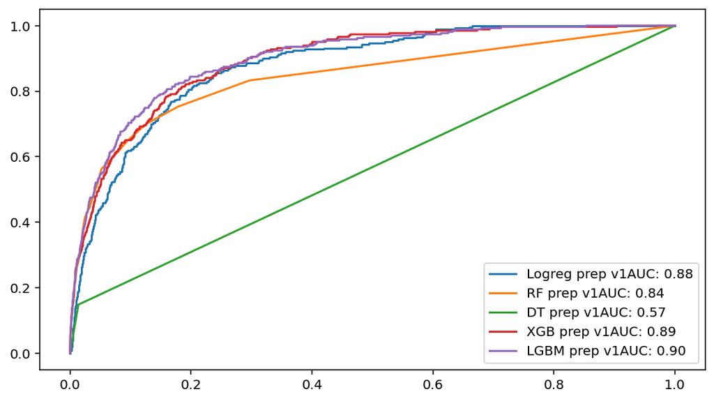

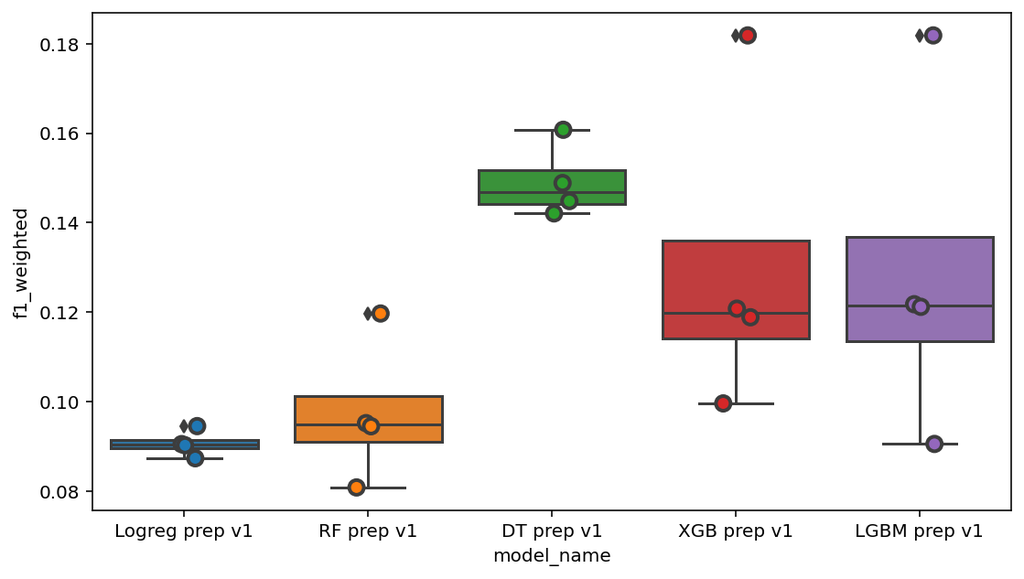

```python
utils.plot_roc_curves_for_evaluation_results(results_bl)
utils.plot_cv_strip_for_evaluation_results(entries_bl)
```

## 3.4 Modeling experiment v2

### Preprocessing setup

1. Delete rows with null target variables ('default')
2. Convert boolean feature to int
3. Impute numeric columns, which contains null data (median strategy)
4. Impute categorical columns, which contains null data (most_frequent strategy)
5. Apply dummies encoding for nominal_categorical_cols
6. Apply scaling for numerical columns

```python
df_bl2 = df[df['default'].isna() == False] #1
df_bl2[boolean_cols] = df_bl2[boolean_cols].astype('int') #2
#3,6
numeric_transformer_imp = Pipeline(steps=[
    ('imputer', SimpleImputer(strategy='median')),
    ('scaler', RobustScaler())])
#4,5
categorical_transformer_imp = Pipeline(steps=[
    ('imputer', SimpleImputer(strategy='most_frequent')),
    ('onehot', OneHotEncoder(handle_unknown='ignore'))])
#3,5
preprocessor2 = ColumnTransformer(
    transformers=[
        ('num', numeric_transformer_imp, numeric_cols  + categorical_num_cols ),
        ('cat', categorical_transformer_imp, categorical_text_cols)])
```

```python
print('Current baseline dataframe shape:', df_bl2.shape)
print('Current baseline dataframe shape (after prep):', preprocessor2.fit_transform(df_bl2).shape)
```

```
Current baseline dataframe shape: (89976, 43)
Current baseline dataframe shape (after prep): (89976, 114)
```

```python
entries_bl2, results_bl2 = utils.evalute_models_cv(estimators,
                  estimators_names,
                  preprocessor2,
                  'prep v2',
                  *train_test_split(
                        df_bl2.drop(['uuid','default'], axis = 1),
                        df_bl2['default'],
                        test_size=0.2,
                        random_state=0)
                 )
```

[output not shown]

```python
results_bl2.sort_values(by = 'f1_test', ascending= False)
```

|  | Name | f1 | f1_test | roc_auc_test | StdDev(%) | Time(s) | fpr | tpr |
| --- | --- | --- | --- | --- | --- | --- | --- | --- |
| 2 | DT prep v2 | 0.1729 | 0.1749 | 0.5845 | 0.60 | 12.52 | [0.0, 0.013421304911746462, 1.0] | [0.0, 0.18250950570342206, 1.0] |
| 4 | LGBM prep v2 | 0.1626 | 0.1600 | 0.9045 | 3.20 | 4.34 | [0.0, 0.0, 0.00011278407488862572, 0.000112784... | [0.0, 0.0038022813688212928, 0.003802281368821... |
| 3 | XGB prep v2 | 0.1634 | 0.1494 | 0.9006 | 3.07 | 24.38 | [0.0, 0.0, 0.0, 5.639203744431286e-05, 5.63920... | [0.0, 0.0038022813688212928, 0.007604562737642... |
| 1 | RF prep v2 | 0.1117 | 0.1168 | 0.8631 | 2.40 | 51.12 | [0.0, 0.0, 5.639203744431286e-05, 5.6392037444... | [0.0, 0.0038022813688212928, 0.003802281368821... |
| 0 | Logreg prep v2 | 0.0718 | 0.0890 | 0.8706 | 1.71 | 6.62 | [0.0, 0.0, 0.0, 5.639203744431286e-05, 5.63920... | [0.0, 0.0038022813688212928, 0.011406844106463... |

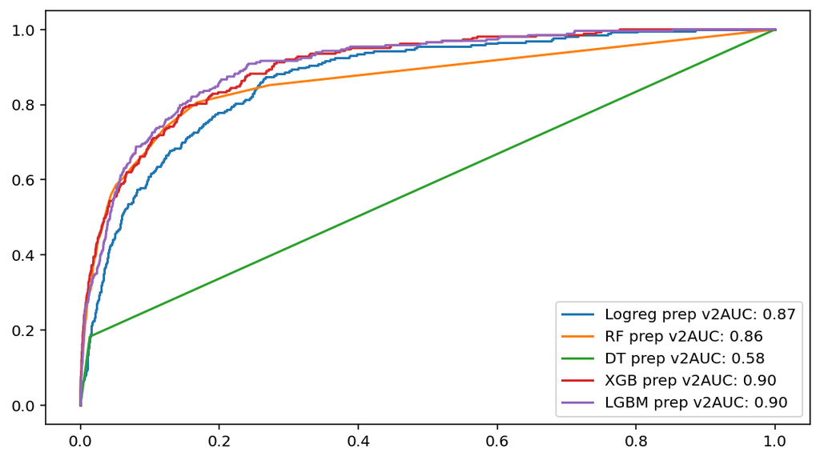

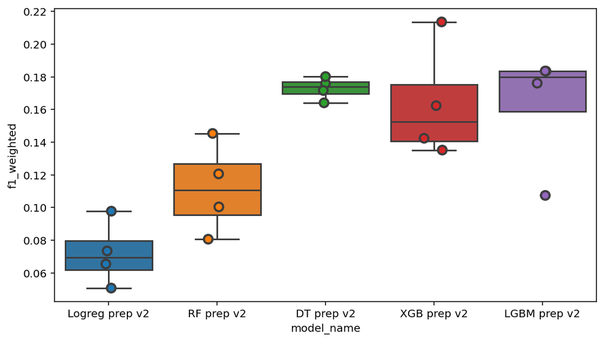

```python
utils.plot_roc_curves_for_evaluation_results(results_bl2)
utils.plot_cv_strip_for_evaluation_results(entries_bl2)
```

We see slight positive effect of data imputation with baseline model.

## 3.5 Modeling experiment v3 (v2 + Feature engineering)

```python
df_bl2['age_bins'] = pd.cut(df_bl2['age'], bins = np.linspace(17, 95, num = 13))

preprocessor2_bins = ColumnTransformer(
    transformers=[
        ('num', numeric_transformer_imp, numeric_cols  + categorical_num_cols ),
        ('cat', categorical_transformer_imp, categorical_text_cols + ['age_bins'])])
```

```python
entries_bl2_bins, results_bl2_bins = utils.evalute_models_cv(estimators,
                  estimators_names,
                  preprocessor2_bins,
                  'prep v2 + fe bins',
                  *train_test_split(
                        df_bl2.drop(['uuid','default'], axis = 1),
                        df_bl2['default'],
                        test_size=0.2,
                        random_state=0)
                 )
```

[output not shown]

```python
results_bl2_bins.sort_values(by = 'f1_test', ascending= False)
```

|  | Name | f1 | f1_test | roc_auc_test | StdDev(%) | Time(s) | fpr | tpr |
| --- | --- | --- | --- | --- | --- | --- | --- | --- |
| 2 | DT prep v2 + fe bins | 0.1663 | 0.1996 | 0.5963 | 1.30 | 15.72 | [0.0, 0.012631816387526081, 1.0] | [0.0, 0.20532319391634982, 1.0] |
| 4 | LGBM prep v2 + fe bins | 0.1630 | 0.1747 | 0.9095 | 2.29 | 6.78 | [0.0, 0.0, 5.639203744431286e-05, 5.6392037444... | [0.0, 0.0038022813688212928, 0.003802281368821... |
| 3 | XGB prep v2 + fe bins | 0.1552 | 0.1377 | 0.9006 | 2.54 | 28.31 | [0.0, 5.639203744431286e-05, 0.000112784074888... | [0.0, 0.0, 0.0, 0.030418250950570342, 0.030418... |
| 1 | RF prep v2 + fe bins | 0.1052 | 0.1172 | 0.8660 | 2.24 | 56.75 | [0.0, 5.639203744431286e-05, 5.639203744431286... | [0.0, 0.0, 0.0076045627376425855, 0.0152091254... |
| 0 | Logreg prep v2 + fe bins | 0.0795 | 0.0959 | 0.8776 | 1.53 | 9.39 | [0.0, 0.0, 0.0, 5.639203744431286e-05, 5.63920... | [0.0, 0.0038022813688212928, 0.007604562737642... |

```python
entries_bl2_fe = []
results_bl2_fe = pd.DataFrame()

for num_top_features in [5,10]:
    for poly_degree in [2,3]:
        print('prep v2 + fe poly' + str(poly_degree) + 'top' + str(num_top_features))

        top_num_corr_features = list(cols_corr_df.index.values[1:num_top_features+1])


        #3,6
        numeric_transformer_imp = Pipeline(steps=[
            ('imputer', SimpleImputer(strategy='median')),
            ('scaler', RobustScaler())])
        #4,5
        categorical_transformer_imp = Pipeline(steps=[
            ('imputer', SimpleImputer(strategy='most_frequent')),
            ('onehot', OneHotEncoder(handle_unknown='ignore'))])

        top_numeric_transformer_imp_poly = Pipeline(steps=[
            ('imputer', SimpleImputer(strategy='median')),
            ('scaler', RobustScaler()),
            ('poly', PolynomialFeatures(degree = poly_degree))
        ])

        #3,5
        preprocessor2_fe = ColumnTransformer(
            transformers=[
                ('num', numeric_transformer_imp, numeric_cols  + categorical_num_cols ),
                ('num_poly_fe', top_numeric_transformer_imp_poly, top_num_corr_features + ['age'] ),
                ('cat', categorical_transformer_imp, categorical_text_cols + ['age_bins'])])

        print('Current dataframe shape:', df_bl2.shape)
        print('Current dataframe shape (after prep):', preprocessor2_fe.fit_transform(df_bl2).shape)

        entries_tmp, results_tmp = utils.evalute_models_cv(estimators,
                  estimators_names,
                  preprocessor2_fe,
                  'prep v2 + fe poly' + str(poly_degree) + 'top' + str(num_top_features) ,
                  *train_test_split(
                        df_bl2.drop(['uuid','default'], axis = 1),
                        df_bl2['default'],
                        test_size=0.2,
                        random_state=0)
                 )
        entries_bl2_fe.append(entries_tmp)
        results_bl2_fe = pd.concat([results_bl2_fe, results_tmp])
```

[output not shown]

[output cut: 18 more lines]

```python
results_bl2_fe.sort_values(by = 'f1_test', ascending= False)
```

|  | Name | f1 | f1_test | roc_auc_test | StdDev(%) | Time(s) | fpr | tpr |
| --- | --- | --- | --- | --- | --- | --- | --- | --- |
| 2 | DT prep v2 + fe poly3top10 | 0.1569 | 0.2039 | 0.6016 | 1.23 | 79.38 | [0.0, 0.013477696949190774, 1.0] | [0.0, 0.21673003802281368, 1.0] |
| 2 | DT prep v2 + fe poly2top10 | 0.1774 | 0.1922 | 0.5958 | 0.56 | 34.34 | [0.0, 0.013816049173856652, 1.0] | [0.0, 0.20532319391634982, 1.0] |
| 3 | XGB prep v2 + fe poly2top5 | 0.1699 | 0.1824 | 0.9012 | 2.35 | 33.95 | [0.0, 5.639203744431286e-05, 0.000169176112332... | [0.0, 0.0, 0.0, 0.0038022813688212928, 0.00380... |
| 3 | XGB prep v2 + fe poly2top10 | 0.1563 | 0.1683 | 0.9002 | 1.04 | 42.80 | [0.0, 5.639203744431286e-05, 0.000169176112332... | [0.0, 0.0, 0.0, 0.011406844106463879, 0.011406... |
| 2 | DT prep v2 + fe poly2top5 | 0.1697 | 0.1673 | 0.5807 | 0.87 | 21.89 | [0.0, 0.0135904810240794, 1.0] | [0.0, 0.17490494296577946, 1.0] |
| 3 | XGB prep v2 + fe poly3top10 | 0.1637 | 0.1667 | 0.9002 | 1.97 | 103.33 | [0.0, 0.0, 5.639203744431286e-05, 5.6392037444... | [0.0, 0.0038022813688212928, 0.003802281368821... |
| 4 | LGBM prep v2 + fe poly3top5 | 0.1505 | 0.1622 | 0.9109 | 3.27 | 8.25 | [0.0, 0.0, 0.0, 5.639203744431286e-05, 5.63920... | [0.0, 0.0038022813688212928, 0.011406844106463... |
| 4 | LGBM prep v2 + fe poly2top10 | 0.1646 | 0.1548 | 0.9060 | 1.05 | 10.17 | [0.0, 0.0, 5.639203744431286e-05, 5.6392037444... | [0.0, 0.0038022813688212928, 0.003802281368821... |
| 4 | LGBM prep v2 + fe poly2top5 | 0.1518 | 0.1441 | 0.9068 | 2.20 | 7.54 | [0.0, 0.0, 0.0, 5.639203744431286e-05, 5.63920... | [0.0, 0.0038022813688212928, 0.007604562737642... |
| 2 | DT prep v2 + fe poly3top5 | 0.1737 | 0.1358 | 0.5634 | 0.24 | 30.58 | [0.0, 0.013816049173856652, 1.0] | [0.0, 0.14068441064638784, 1.0] |
| 3 | XGB prep v2 + fe poly3top5 | 0.1566 | 0.1311 | 0.8997 | 2.09 | 43.81 | [0.0, 5.639203744431286e-05, 5.639203744431286... | [0.0, 0.0, 0.011406844106463879, 0.01140684410... |
| 4 | LGBM prep v2 + fe poly3top10 | 0.1811 | 0.1288 | 0.9066 | 1.25 | 12.60 | [0.0, 5.639203744431286e-05, 0.000451136299554... | [0.0, 0.0, 0.0, 0.011406844106463879, 0.011406... |
| 1 | RF prep v2 + fe poly2top5 | 0.1379 | 0.1192 | 0.8647 | 2.86 | 76.06 | [0.0, 5.639203744431286e-05, 5.639203744431286... | [0.0, 0.0, 0.011406844106463879, 0.01901140684... |
| 1 | RF prep v2 + fe poly2top10 | 0.1426 | 0.1137 | 0.8676 | 3.32 | 104.63 | [0.0, 5.639203744431286e-05, 5.639203744431286... | [0.0, 0.0, 0.011406844106463879, 0.01901140684... |
| 1 | RF prep v2 + fe poly3top10 | 0.1382 | 0.1104 | 0.8683 | 2.04 | 211.11 | [0.0, 5.639203744431286e-05, 5.639203744431286... | [0.0, 0.0, 0.0076045627376425855, 0.0152091254... |
| 0 | Logreg prep v2 + fe poly2top5 | 0.0857 | 0.1042 | 0.8818 | 1.51 | 10.68 | [0.0, 0.0, 0.0, 5.639203744431286e-05, 5.63920... | [0.0, 0.0038022813688212928, 0.011406844106463... |
| 1 | RF prep v2 + fe poly3top5 | 0.1350 | 0.1007 | 0.8658 | 2.51 | 104.75 | [0.0, 5.639203744431286e-05, 5.639203744431286... | [0.0, 0.0, 0.0038022813688212928, 0.0114068441... |
| 0 | Logreg prep v2 + fe poly3top5 | 0.0726 | 0.0828 | 0.8654 | 0.82 | 13.15 | [0.0, 0.0, 0.0, 5.639203744431286e-05, 5.63920... | [0.0, 0.0076045627376425855, 0.022813688212927... |
| 0 | Logreg prep v2 + fe poly2top10 | 0.0751 | 0.0818 | 0.8663 | 0.49 | 12.45 | [0.0, 5.639203744431286e-05, 5.639203744431286... | [0.0, 0.0038022813688212928, 0.007604562737642... |
| 0 | Logreg prep v2 + fe poly3top10 | 0.0453 | 0.0459 | 0.7127 | 0.10 | 22.79 | [0.0, 0.0, 0.0003383522246658772, 0.0003383522... | [0.0, 0.0076045627376425855, 0.007604562737642... |

## 3.6 Experiments intermediate results

```python
results_concat = pd.concat([results_bl,
results_bl2,
results_bl2_bins,
results_bl2_fe,])
results_concat
results_concat['exp_group'] = results_concat['Name'].apply(lambda v: ' '.join(v.split(' ')[1:]))
```

```python
results_concat.sort_values(by = 'roc_auc_test', ascending = False)
```

|  | Name | f1 | f1_test | roc_auc_test | StdDev(%) | Time(s) | fpr | tpr | exp_group |
| --- | --- | --- | --- | --- | --- | --- | --- | --- | --- |
| 4 | LGBM prep v2 + fe poly3top5 | 0.1505 | 0.1622 | 0.9109 | 3.27 | 8.25 | [0.0, 0.0, 0.0, 5.639203744431286e-05, 5.63920... | [0.0, 0.0038022813688212928, 0.011406844106463... | prep v2 + fe poly3top5 |
| 4 | LGBM prep v2 + fe bins | 0.1630 | 0.1747 | 0.9095 | 2.29 | 6.78 | [0.0, 0.0, 5.639203744431286e-05, 5.6392037444... | [0.0, 0.0038022813688212928, 0.003802281368821... | prep v2 + fe bins |
| 4 | LGBM prep v2 + fe poly2top5 | 0.1518 | 0.1441 | 0.9068 | 2.20 | 7.54 | [0.0, 0.0, 0.0, 5.639203744431286e-05, 5.63920... | [0.0, 0.0038022813688212928, 0.007604562737642... | prep v2 + fe poly2top5 |
| 4 | LGBM prep v2 + fe poly3top10 | 0.1811 | 0.1288 | 0.9066 | 1.25 | 12.60 | [0.0, 5.639203744431286e-05, 0.000451136299554... | [0.0, 0.0, 0.0, 0.011406844106463879, 0.011406... | prep v2 + fe poly3top10 |
| 4 | LGBM prep v2 + fe poly2top10 | 0.1646 | 0.1548 | 0.9060 | 1.05 | 10.17 | [0.0, 0.0, 5.639203744431286e-05, 5.6392037444... | [0.0, 0.0038022813688212928, 0.003802281368821... | prep v2 + fe poly2top10 |
| 4 | LGBM prep v2 | 0.1626 | 0.1600 | 0.9045 | 3.20 | 4.34 | [0.0, 0.0, 0.00011278407488862572, 0.000112784... | [0.0, 0.0038022813688212928, 0.003802281368821... | prep v2 |
| 3 | XGB prep v2 + fe poly2top5 | 0.1699 | 0.1824 | 0.9012 | 2.35 | 33.95 | [0.0, 5.639203744431286e-05, 0.000169176112332... | [0.0, 0.0, 0.0, 0.0038022813688212928, 0.00380... | prep v2 + fe poly2top5 |
| 3 | XGB prep v2 | 0.1634 | 0.1494 | 0.9006 | 3.07 | 24.38 | [0.0, 0.0, 0.0, 5.639203744431286e-05, 5.63920... | [0.0, 0.0038022813688212928, 0.007604562737642... | prep v2 |
| 3 | XGB prep v2 + fe bins | 0.1552 | 0.1377 | 0.9006 | 2.54 | 28.31 | [0.0, 5.639203744431286e-05, 0.000112784074888... | [0.0, 0.0, 0.0, 0.030418250950570342, 0.030418... | prep v2 + fe bins |
| 3 | XGB prep v2 + fe poly3top10 | 0.1637 | 0.1667 | 0.9002 | 1.97 | 103.33 | [0.0, 0.0, 5.639203744431286e-05, 5.6392037444... | [0.0, 0.0038022813688212928, 0.003802281368821... | prep v2 + fe poly3top10 |
| 3 | XGB prep v2 + fe poly2top10 | 0.1563 | 0.1683 | 0.9002 | 1.04 | 42.80 | [0.0, 5.639203744431286e-05, 0.000169176112332... | [0.0, 0.0, 0.0, 0.011406844106463879, 0.011406... | prep v2 + fe poly2top10 |
| 3 | XGB prep v2 + fe poly3top5 | 0.1566 | 0.1311 | 0.8997 | 2.09 | 43.81 | [0.0, 5.639203744431286e-05, 5.639203744431286... | [0.0, 0.0, 0.011406844106463879, 0.01140684410... | prep v2 + fe poly3top5 |
| 4 | LGBM prep v1 | 0.1289 | 0.1180 | 0.8985 | 3.31 | 2.79 | [0.0, 0.0, 0.0, 0.00011278407488862572, 0.0001... | [0.0, 0.0038022813688212928, 0.011406844106463... | prep v1 |
| 3 | XGB prep v1 | 0.1303 | 0.1141 | 0.8931 | 3.09 | 12.76 | [0.0, 5.639203744431286e-05, 0.000112784074888... | [0.0, 0.0, 0.0, 0.019011406844106463, 0.019011... | prep v1 |
| 0 | Logreg prep v2 + fe poly2top5 | 0.0857 | 0.1042 | 0.8818 | 1.51 | 10.68 | [0.0, 0.0, 0.0, 5.639203744431286e-05, 5.63920... | [0.0, 0.0038022813688212928, 0.011406844106463... | prep v2 + fe poly2top5 |
| 0 | Logreg prep v1 | 0.0907 | 0.0970 | 0.8776 | 0.26 | 3.86 | [0.0, 0.0, 0.00039474426211019004, 0.000394744... | [0.0, 0.0038022813688212928, 0.003802281368821... | prep v1 |
| 0 | Logreg prep v2 + fe bins | 0.0795 | 0.0959 | 0.8776 | 1.53 | 9.39 | [0.0, 0.0, 0.0, 5.639203744431286e-05, 5.63920... | [0.0, 0.0038022813688212928, 0.007604562737642... | prep v2 + fe bins |
| 0 | Logreg prep v2 | 0.0718 | 0.0890 | 0.8706 | 1.71 | 6.62 | [0.0, 0.0, 0.0, 5.639203744431286e-05, 5.63920... | [0.0, 0.0038022813688212928, 0.011406844106463... | prep v2 |
| 1 | RF prep v2 + fe poly3top10 | 0.1382 | 0.1104 | 0.8683 | 2.04 | 211.11 | [0.0, 5.639203744431286e-05, 5.639203744431286... | [0.0, 0.0, 0.0076045627376425855, 0.0152091254... | prep v2 + fe poly3top10 |
| 1 | RF prep v2 + fe poly2top10 | 0.1426 | 0.1137 | 0.8676 | 3.32 | 104.63 | [0.0, 5.639203744431286e-05, 5.639203744431286... | [0.0, 0.0, 0.011406844106463879, 0.01901140684... | prep v2 + fe poly2top10 |
| 0 | Logreg prep v2 + fe poly2top10 | 0.0751 | 0.0818 | 0.8663 | 0.49 | 12.45 | [0.0, 5.639203744431286e-05, 5.639203744431286... | [0.0, 0.0038022813688212928, 0.007604562737642... | prep v2 + fe poly2top10 |
| 1 | RF prep v2 + fe bins | 0.1052 | 0.1172 | 0.8660 | 2.24 | 56.75 | [0.0, 5.639203744431286e-05, 5.639203744431286... | [0.0, 0.0, 0.0076045627376425855, 0.0152091254... | prep v2 + fe bins |
| 1 | RF prep v2 + fe poly3top5 | 0.1350 | 0.1007 | 0.8658 | 2.51 | 104.75 | [0.0, 5.639203744431286e-05, 5.639203744431286... | [0.0, 0.0, 0.0038022813688212928, 0.0114068441... | prep v2 + fe poly3top5 |
| 0 | Logreg prep v2 + fe poly3top5 | 0.0726 | 0.0828 | 0.8654 | 0.82 | 13.15 | [0.0, 0.0, 0.0, 5.639203744431286e-05, 5.63920... | [0.0, 0.0076045627376425855, 0.022813688212927... | prep v2 + fe poly3top5 |
| 1 | RF prep v2 + fe poly2top5 | 0.1379 | 0.1192 | 0.8647 | 2.86 | 76.06 | [0.0, 5.639203744431286e-05, 5.639203744431286... | [0.0, 0.0, 0.011406844106463879, 0.01901140684... | prep v2 + fe poly2top5 |
| 1 | RF prep v2 | 0.1117 | 0.1168 | 0.8631 | 2.40 | 51.12 | [0.0, 0.0, 5.639203744431286e-05, 5.6392037444... | [0.0, 0.0038022813688212928, 0.003802281368821... | prep v2 |
| 1 | RF prep v1 | 0.0976 | 0.0783 | 0.8427 | 1.40 | 115.84 | [0.0, 5.639203744431286e-05, 5.639203744431286... | [0.0, 0.0, 0.011406844106463879, 0.01140684410... | prep v1 |
| 0 | Logreg prep v2 + fe poly3top10 | 0.0453 | 0.0459 | 0.7127 | 0.10 | 22.79 | [0.0, 0.0, 0.0003383522246658772, 0.0003383522... | [0.0, 0.0076045627376425855, 0.007604562737642... | prep v2 + fe poly3top10 |
| 2 | DT prep v2 + fe poly3top10 | 0.1569 | 0.2039 | 0.6016 | 1.23 | 79.38 | [0.0, 0.013477696949190774, 1.0] | [0.0, 0.21673003802281368, 1.0] | prep v2 + fe poly3top10 |
| 2 | DT prep v2 + fe bins | 0.1663 | 0.1996 | 0.5963 | 1.30 | 15.72 | [0.0, 0.012631816387526081, 1.0] | [0.0, 0.20532319391634982, 1.0] | prep v2 + fe bins |
| 2 | DT prep v2 + fe poly2top10 | 0.1774 | 0.1922 | 0.5958 | 0.56 | 34.34 | [0.0, 0.013816049173856652, 1.0] | [0.0, 0.20532319391634982, 1.0] | prep v2 + fe poly2top10 |
| 2 | DT prep v2 | 0.1729 | 0.1749 | 0.5845 | 0.60 | 12.52 | [0.0, 0.013421304911746462, 1.0] | [0.0, 0.18250950570342206, 1.0] | prep v2 |
| 2 | DT prep v2 + fe poly2top5 | 0.1697 | 0.1673 | 0.5807 | 0.87 | 21.89 | [0.0, 0.0135904810240794, 1.0] | [0.0, 0.17490494296577946, 1.0] | prep v2 + fe poly2top5 |
| 2 | DT prep v1 | 0.1491 | 0.1429 | 0.5673 | 0.71 | 10.76 | [0.0, 0.013759657136412338, 1.0] | [0.0, 0.1482889733840304, 1.0] | prep v1 |
| 2 | DT prep v2 + fe poly3top5 | 0.1737 | 0.1358 | 0.5634 | 0.24 | 30.58 | [0.0, 0.013816049173856652, 1.0] | [0.0, 0.14068441064638784, 1.0] | prep v2 + fe poly3top5 |

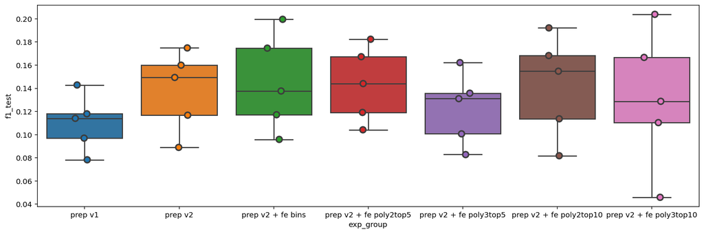

```python
plt.figure(figsize = (16,5))
sns.boxplot(x='exp_group', y='f1_test', data=results_concat[['exp_group', 'f1_test']])
sns.stripplot(x='exp_group', y='f1_test', data=results_concat[['exp_group', 'f1_test']],
              size=8, jitter=True, edgecolor="gray", linewidth=2)
#plt.xticks(rotation=-90)
plt.show()
```

## 3.7 Modeling experiment v4 (v2 + Feature engineering + SMOTE)

```python
X_train, X_test, y_train, y_test = train_test_split(
    df_bl2.drop(['uuid','default'], axis = 1),
    df_bl2['default'],
    test_size=0.2,
    random_state=0)
```

### Best Preprocessing

```python
num_top_features = 5
poly_degree = 2

top_num_corr_features = list(cols_corr_df.index.values[1:num_top_features+1])

numeric_transformer_imp = Pipeline(steps=[
    ('imputer', SimpleImputer(strategy='median')),
    ('scaler', RobustScaler())])
#4,5
categorical_transformer_imp = Pipeline(steps=[
    ('imputer', SimpleImputer(strategy='most_frequent')),
    ('onehot', OneHotEncoder(handle_unknown='ignore'))])

top_numeric_transformer_imp_poly = Pipeline(steps=[
    ('imputer', SimpleImputer(strategy='median')),
    ('scaler', RobustScaler()),
    ('poly', PolynomialFeatures(degree = poly_degree))
])

#3,5
preprocessor2_best = ColumnTransformer(
    transformers=[
        ('num', numeric_transformer_imp, numeric_cols  + categorical_num_cols ),
        ('num_poly_fe', top_numeric_transformer_imp_poly, top_num_corr_features + ['age'] ),
        ('cat', categorical_transformer_imp, categorical_text_cols + ['age_bins'])])
```

```python
X_train.columns
```

```
Index(['account_amount_added_12_24m', 'account_days_in_dc_12_24m',
       'account_days_in_rem_12_24m', 'account_days_in_term_12_24m',
       'account_incoming_debt_vs_paid_0_24m', 'account_status',
       'account_worst_status_0_3m', 'account_worst_status_12_24m',
       'account_worst_status_3_6m', 'account_worst_status_6_12m', 'age',
       'avg_payment_span_0_12m', 'avg_payment_span_0_3m', 'merchant_category',
       'merchant_group', 'has_paid', 'max_paid_inv_0_12m',
       'max_paid_inv_0_24m', 'name_in_email',
       'num_active_div_by_paid_inv_0_12m', 'num_active_inv',
       'num_arch_dc_0_12m', 'num_arch_dc_12_24m', 'num_arch_ok_0_12m',
       'num_arch_ok_12_24m', 'num_arch_rem_0_12m',
       'num_arch_written_off_0_12m', 'num_arch_written_off_12_24m',
       'num_unpaid_bills', 'status_last_archived_0_24m',
       'status_2nd_last_archived_0_24m', 'status_3rd_last_archived_0_24m',
       'status_max_archived_0_6_months', 'status_max_archived_0_12_months',
       'status_max_archived_0_24_months', 'recovery_debt',
       'sum_capital_paid_account_0_12m', 'sum_capital_paid_account_12_24m',
       'sum_paid_inv_0_12m', 'time_hours', 'worst_status_active_inv',
       'age_bins'],
      dtype='object')
```

```python
X_train_prep = preprocessor2_best.fit_transform(X_train)
X_test_prep = preprocessor2_best.transform(X_test)
```

```python
print('Train shape', X_train_prep.shape)
print('Test shape', X_test_prep.shape)
```

```
Train shape (71980, 154)
Test shape (17996, 154)
```

```python
from imblearn.over_sampling import SMOTE
from imblearn.combine import SMOTEENN
sm = SMOTE(random_state=42)

smt = SMOTEENN(random_state=42)
#X, y = smt.fit_sample(X, y)


X_train_prep_smt, y_train_smt = smt.fit_resample(X_train_prep, y_train)
```

```python
y_train_smt.value_counts()
```

```
1.0    70136
0.0    64887
Name: default, dtype: int64
```

```python
entries_bl2_fe_smt, results_bl2_fe_smt = utils.evalute_models_cv(estimators,
                  estimators_names,
                  None, #cached preprocessed data already passed as in function because of smote
                  'prep v2 + fe poly2top5 + smote',
                  X_train_prep_smt, #after smote + prepv2
                  X_test_prep, #after prepv2
                  y_train_smt, #after smote
                  y_test,
                 )
```

[output not shown]

```python
results_concat = pd.concat([results_bl,
results_bl2,
results_bl2_bins,
results_bl2_fe,
results_bl2_fe_smt])
results_concat['exp_group'] = results_concat['Name'].apply(lambda v: ' '.join(v.split(' ')[1:]))
```

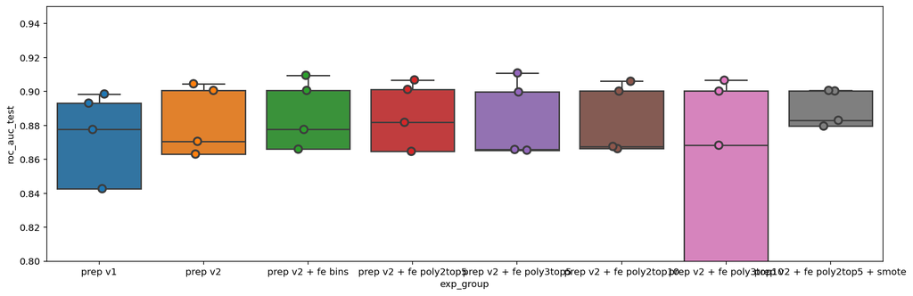

```python
plt.figure(figsize = (16,5))
sns.boxplot(x='exp_group', y='roc_auc_test', data=results_concat[['exp_group', 'roc_auc_test']])
sns.stripplot(x='exp_group', y='roc_auc_test', data=results_concat[['exp_group', 'roc_auc_test']],
              size=8, jitter=True, edgecolor="gray", linewidth=2)
#plt.xticks(rotation=-90)
plt.ylim([0.8,0.95])
plt.show()
```

## 3.8 Experiments final results

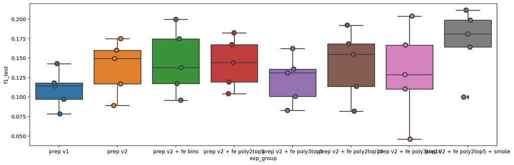

```python
plt.figure(figsize = (16,5))
sns.boxplot(x='exp_group', y='f1_test', data=results_concat[['exp_group', 'f1_test']])
sns.stripplot(x='exp_group', y='f1_test', data=results_concat[['exp_group', 'f1_test']],
              size=8, jitter=True, edgecolor="gray", linewidth=2)
#plt.xticks(rotation=-90)
plt.show()
```

SmoteKNN sampling gives boost to all models (except logreg)! Let's choose the final model:

```python
results_concat.sort_values(by = 'f1_test', ascending= False).head(5)
```

|  | Name | f1 | f1_test | roc_auc_test | StdDev(%) | Time(s) | fpr | tpr | exp_group |
| --- | --- | --- | --- | --- | --- | --- | --- | --- | --- |
| 4 | LGBM prep v2 + fe poly2top5 + smote | 0.9927 | 0.2116 | 0.9006 | 0.03 | 6.33 | [0.0, 5.639203744431286e-05, 0.000169176112332... | [0.0, 0.0, 0.0, 0.011406844106463879, 0.011406... | prep v2 + fe poly2top5 + smote |
| 2 | DT prep v2 + fe poly3top10 | 0.1569 | 0.2039 | 0.6016 | 1.23 | 79.38 | [0.0, 0.013477696949190774, 1.0] | [0.0, 0.21673003802281368, 1.0] | prep v2 + fe poly3top10 |
| 2 | DT prep v2 + fe bins | 0.1663 | 0.1996 | 0.5963 | 1.30 | 15.72 | [0.0, 0.012631816387526081, 1.0] | [0.0, 0.20532319391634982, 1.0] | prep v2 + fe bins |
| 3 | XGB prep v2 + fe poly2top5 + smote | 0.9933 | 0.1986 | 0.9003 | 0.02 | 65.99 | [0.0, 0.0, 0.00011278407488862572, 0.000112784... | [0.0, 0.0038022813688212928, 0.003802281368821... | prep v2 + fe poly2top5 + smote |
| 2 | DT prep v2 + fe poly2top10 | 0.1774 | 0.1922 | 0.5958 | 0.56 | 34.34 | [0.0, 0.013816049173856652, 1.0] | [0.0, 0.20532319391634982, 1.0] | prep v2 + fe poly2top10 |

```python
print('Total experiments:', len(results_concat))
```

```
Total experiments: 40
```

### 3.8.1 Testing best model

Testing LGBMClassifier Classifier again (+ class rep):

```
F1-score: 0.21
AUC: 0.90

Classification report:
              precision    recall  f1-score   support

 Default = 0       0.99      0.99      0.99     17733
 Default = 1       0.23      0.19      0.21       263

    accuracy                           0.98     17996
   macro avg       0.61      0.59      0.60     17996
weighted avg       0.98      0.98      0.98     17996
```

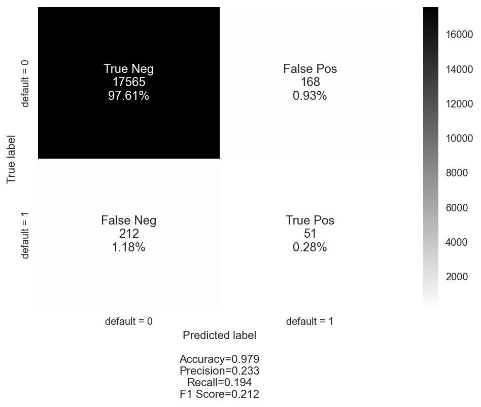

```python
utils.fit_predict_after_split(
    LGBMClassifier(),
    X_train_prep_smt, #after smote + prepv2
    X_test_prep, #after prepv2
    y_train_smt, #after smote
    y_test
)
```

### 3.8.2 Threshold analysis

```python
lgbm_model = LGBMClassifier()
lgbm_model.fit(X_train_prep_smt, y_train_smt)
```

```
LGBMClassifier()
```

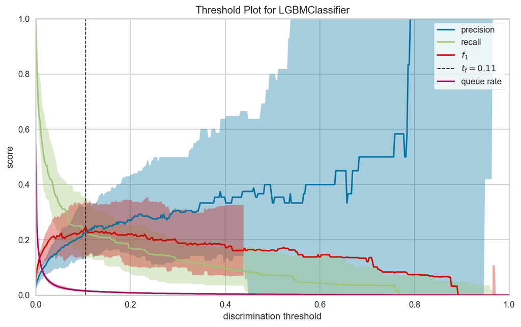

```python
from yellowbrick.classifier import DiscriminationThreshold

fig, ax = plt.subplots(figsize=(10, 6))
model_viz = DiscriminationThreshold(lgbm_model, fitted = True)
model_viz.fit(X_test_prep, y_test)
model_viz.poof();
```

# 4. Business interpretation

We have chosen best model based on f1-score for positive class (default = 1), it is just general purpose - let's try to do out best and build a model, which can be good at both concerns (precision and recall). Recall for positive class with default threshold equals to 0.19, whick means, that 19% of clients with flag "is risk of default" would be classified correctly.

But this interpretation can be different for different business tasks.

For example, if we will use this model for **onboarding new clients**, we should understand, that the profit on good customer loan is not equal to the loss on one bad customer loan. So, in this case, we should set up the threshold for our model so that recall is high.

For example, we can do something like this (threshold = 0.1):

```
F1-score: 0.16
AUC: 0.90

Classification report:
              precision    recall  f1-score   support

 Default = 0       1.00      0.90      0.94     17733
 Default = 1       0.09      0.71      0.16       263

    accuracy                           0.89     17996
   macro avg       0.54      0.80      0.55     17996
weighted avg       0.98      0.89      0.93     17996
```

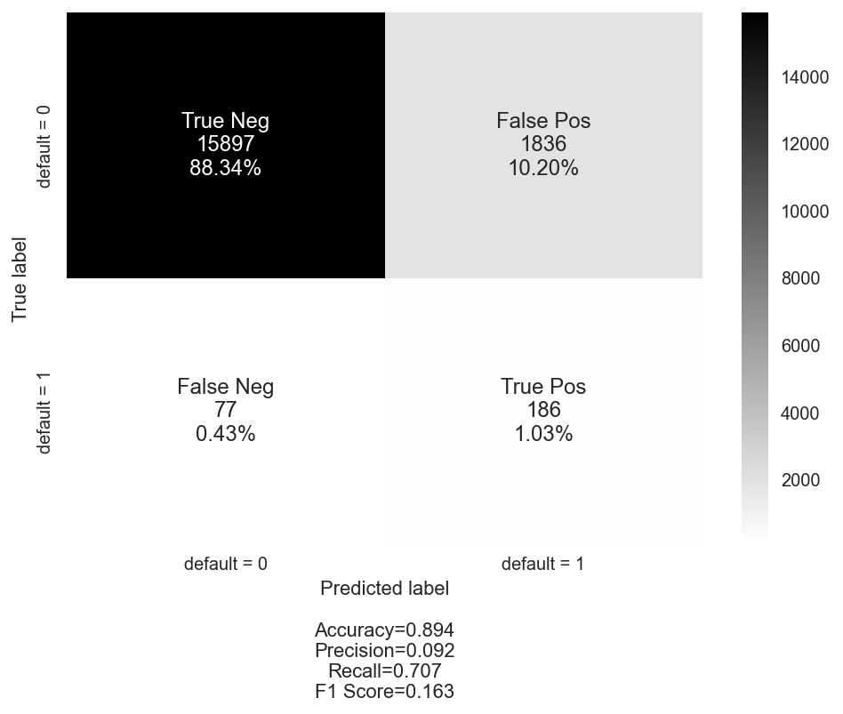

```python
utils.fit_predict_after_split(
    LGBMClassifier(),
    X_train_prep_smt, #after smote + prepv2
    X_test_prep, #after prepv2
    y_train_smt, #after smote
    y_test,
    threshold = 0.1
)
```

Now we see that Recall = 0.7 - 70% of clients with flag "in risk of default" classified correctly. But we have some consequences: 10% of our "good" clients may be mistakenly categorized as "default". Is it better for business? Will there be a positive economic effect from such a threshold? ...

So we should clearly identify the business goal of our model, talk to stakeholders and only after that we can choose appropriate evaluation strategy/appropriate metric.

# 5. Further improvements (out of scope for now)

1. Run grid_search for tuning model hyperparameters (i guess this stage can give +0.1 F1-score max)
2. Find best threshold for predictions
3. Do more precise and targeted EDA for some finding useful insights about each feature
4. Do feature importance analysis(shap values etc)
5. Do feature engineering with rescept to deeper understanding of business processes
6. Deal with missing target variables (maybe apply pseudo-labeling technique..)

# 6. Deployment

See **/deploy** directory for deployment package and **/dev-klarna-case-study-paul.postman_collection.json** for how to query the endpoint.